# **数据挖掘 第五次作业**

邓淇升** **16307110232** **大数据学院

15 Apr 2019

## **TASK 0**

在数据分析之前，先进行环境设置等准备工作。

```r
## 清空命令行窗口
cat('\014')
```

```r
## 清空工作变量
rm(list = ls())

## 加载所需的包
library(dplyr)
library(lubridate)
library(ggplot2)
library(gridExtra)
library(MASS)
library(plyr)
library(pROC)
library(RColorBrewer)
library(ROCR)
library(Rwordseg)
library(scales)
library(stringr)
library(tm)
library(wordcloud2)

## 设置系统工作路径
setwd('F:\\复旦大学\\课程课件\\新大二下学期\\1 数据挖掘\\Homework\\第5次作业')

## 设置字体样式
windowsFonts(chineseFont = windowsFont('等线'))
windowsFonts(mathFont = windowsFont('Calibri'))
```

## **TASK 1**

读入火锅团购资料的数据集，修改数据类型，查看数据记录的基本情况。观察发现，数据集中已经预设好分类变量，建立回归模型时可以直接提取使用。

```r
## 读入数据集hot.pot
hot.pot <- read.csv('HotPotForMac.csv', header = T, fileEncoding = 'UTF-8')

## 设置“字段1”和“字段2”的数据格式为字符
hot.pot$'字段1' <- as.character(hot.pot$'字段1')
hot.pot$'字段2' <- as.character(hot.pot$'字段2')

## 修改字段名称为商家店名和附加信息
names(hot.pot)[2:3] <- c('merchant.name', 'additional.information')

## 查看数据记录情况
summary(hot.pot)
```

```
##        ID         merchant.name      additional.information
##  Min.   :   1.0   Length:2688        Length:2688
##  1st Qu.: 749.8   Class :character   Class :character
##  Median :1540.5   Mode  :character   Mode  :character
##  Mean   :1548.1
##  3rd Qu.:2350.2
##  Max.   :3150.0
##
##     discount           price                    privilege.for.new
##  Min.   :0.01429   Min.   :   1.00   钱包新客最高再减20元:2639
##  1st Qu.:0.63762   1st Qu.:  68.00   无钱包新客优惠      :  49
##  Median :0.76336   Median :  86.05
##  Mean   :0.72725   Mean   : 109.74
##  3rd Qu.:0.85000   3rd Qu.: 135.25
##  Max.   :0.99900   Max.   :1365.00
##
##   privilege.on.sale    district           if.nonworkdays.available
##  无立减优惠:2537    未央区 :531   非周末法定节假日通用: 403
##  有立减优惠: 151    雁塔区 :436   周末法定节假日通用  :2285
##                     碑林区 :367
##                     莲湖区 :356
##                     长安区 :231
##                     新城区 :173
##                     (Other):594
##  time.duration   if.appointment.needed  WiFi.available       parking
##  Min.   : 0.00   无需预约:2474         免费WiFi:2103   免费停车位: 479
##  1st Qu.:10.00   需预约  : 214         未提及  : 585   收费停车位: 203
##  Median :11.00                                         未提及    :1412
##  Mean   :10.67                                         无停车位  : 594
##  3rd Qu.:12.00
##  Max.   :24.00
##
##      rooms.available      评分           评论数        online.intervel
##  仅限大厅使用:1937   Min.   :0.000   Min.   :   0.00   Min.   :   1.0
##  均可使用    : 500   1st Qu.:0.000   1st Qu.:   0.00   1st Qu.: 191.0
##  未提及      : 251   Median :4.400   Median :   3.00   Median : 320.5
##                      Mean   :3.167   Mean   :  54.49   Mean   : 341.2
##                      3rd Qu.:4.700   3rd Qu.:  22.00   3rd Qu.: 467.0
##                      Max.   :5.000   Max.   :8032.00   Max.   :1143.0
##
```

[output cut: 9 more lines]

```
##  不限张数:2263            否:2108   否:1824   否:2123   否:2150
##  限制张数: 425            是: 580   是: 864   是: 565   是: 538
##
##
##
##
##
##  people     style         HighFreq
##  否:2497   北系: 142   Min.   :0.000
##  是: 191   川系: 861   1st Qu.:1.000
##            其他:1619   Median :2.000
##            粤系:  66   Mean   :1.924
##                        3rd Qu.:3.000
##                        Max.   :6.000
##
```

## **TASK 2**

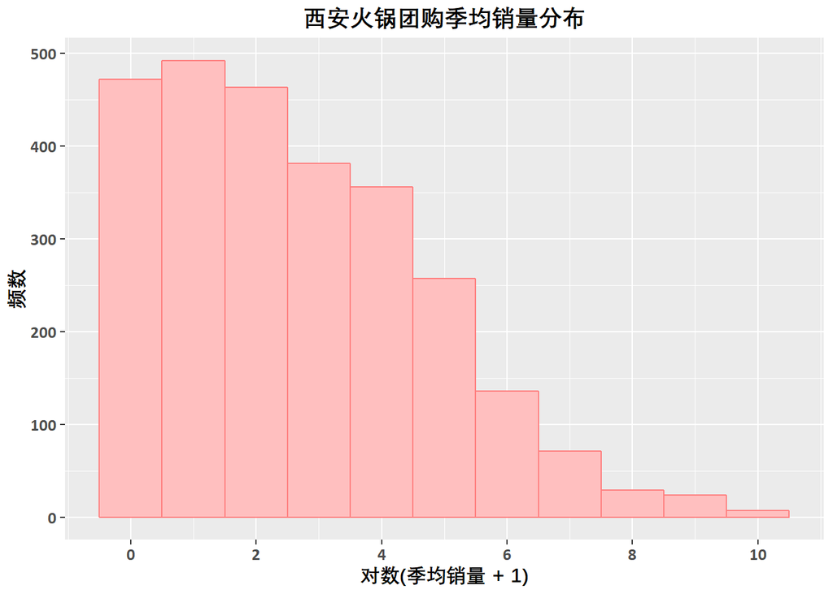

```r
## 将季均销量转换为对数季均销量log.quarterly.sales.volume
hot.pot$log.quarterly.sales.volume <- log(hot.pot$quarterly.sales.volume + 1)

## 绘制对数季均销量的分布直方图
ggplot(hot.pot, aes(log.quarterly.sales.volume)) +
    geom_histogram(bins = 12, binwidth = 1, fill = '#FFBFBF', color = '#FF7F7F') +
    labs(x = '对数(季均销量 + 1)', y = '频数', title ='西安火锅团购季均销量分布') +
    theme(title = element_text(family = 'chineseFont', face = 'bold', size = 12)) +
    theme(plot.title = element_text(hjust = 0.5)) +
    theme(axis.text.x = element_text(family = 'mathFont', face = 'bold', size = 10)) +
    theme(axis.text.y = element_text(family = 'mathFont', face = 'bold', size = 10)) +
    scale_x_continuous(breaks = seq(0, 10, 2))
```

```r
## 查看季均销量的基本统计值
summary(hot.pot$quarterly.sales.volume)
```

```
##      Min.   1st Qu.    Median      Mean   3rd Qu.      Max.
##     0.000     1.415     9.441   223.914    55.794 25941.429
```

```r
## 查看季均销量为0的数量
sum(hot.pot$quarterly.sales.volume == 0)
```

```
## [1] 276
```

## **TASK 3**

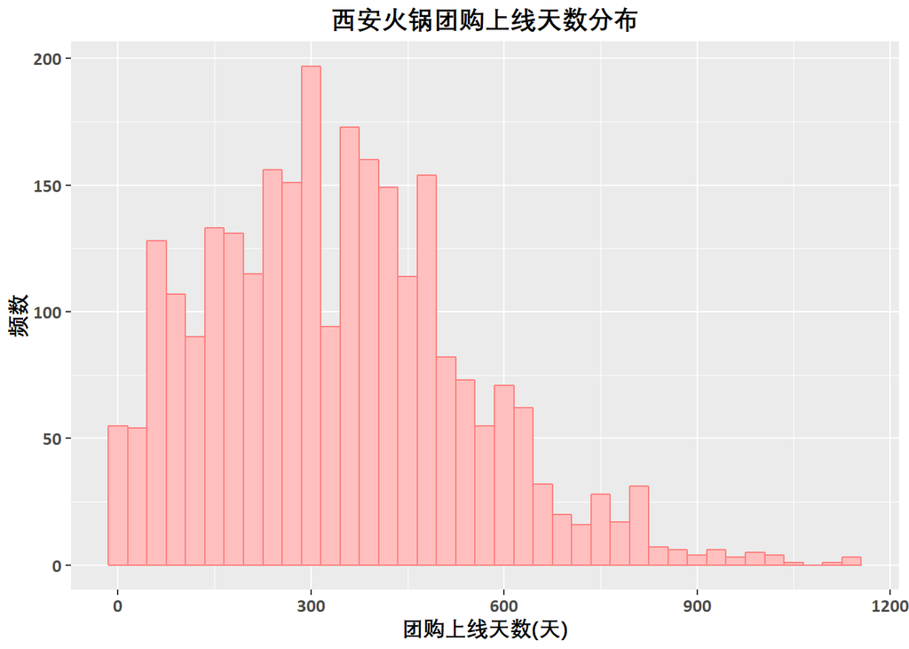

```r
## 绘制上线天数的分布直方图
ggplot(hot.pot, aes(online.intervel)) +
    geom_histogram(binwidth = 30, fill = '#FFBFBF', color = '#FF7F7F') +
    labs(x = '团购上线天数(天)', y = '频数', title ='西安火锅团购上线天数分布') +
    theme(title = element_text(family = 'chineseFont', face = 'bold', size = 12)) +
    theme(plot.title = element_text(hjust = 0.5)) +
    theme(axis.text.x = element_text(family = 'mathFont', face = 'bold', size = 10)) +
    theme(axis.text.y = element_text(family = 'mathFont', face = 'bold', size = 10)) +
    scale_x_continuous(breaks = seq(0, 1200, 300))
```

```r
## 查看上线天数的基本统计值
summary(hot.pot$online.intervel)
```

```
##    Min. 1st Qu.  Median    Mean 3rd Qu.    Max.
##     1.0   191.0   320.5   341.2   467.0  1143.0
```

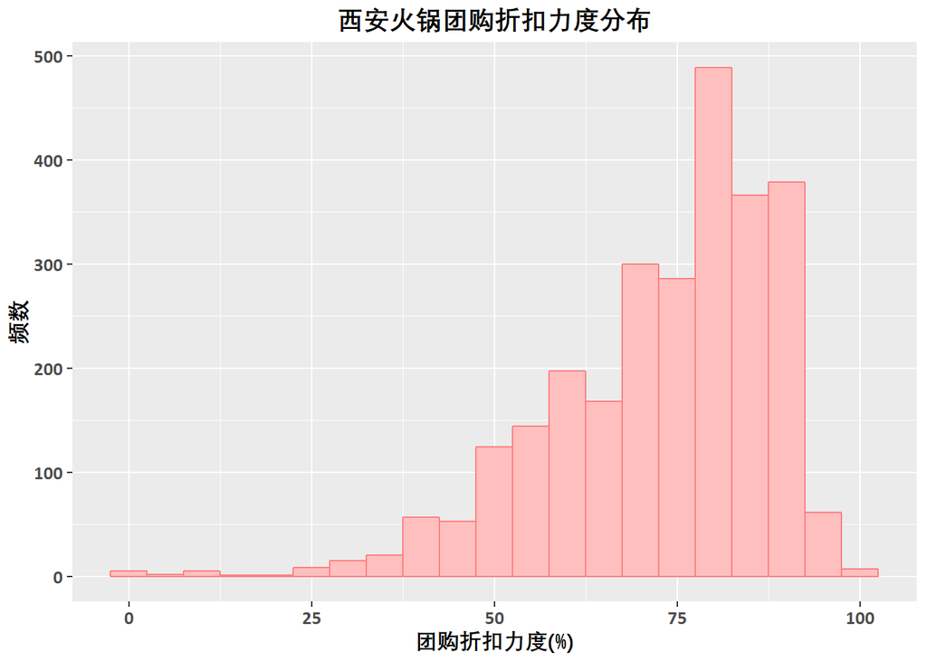

```r
## 绘制折扣力度的分布直方图
ggplot(hot.pot, aes(100 * discount)) +
    geom_histogram(binwidth = 5, fill = '#FFBFBF', color = '#FF7F7F') +
    labs(x = '团购折扣力度(%)', y = '频数', title ='西安火锅团购折扣力度分布') +
    theme(title = element_text(family = 'chineseFont', face = 'bold', size = 12)) +
    theme(plot.title = element_text(hjust = 0.5)) +
    theme(axis.text.x = element_text(family = 'mathFont', face = 'bold', size = 10)) +
    theme(axis.text.y = element_text(family = 'mathFont', face = 'bold', size = 10)) +
    scale_x_continuous(breaks = seq(0, 100, 25))
```

```r
## 查看上线天数的基本统计值
summary(hot.pot$discount)
```

```
##    Min. 1st Qu.  Median    Mean 3rd Qu.    Max.
## 0.01429 0.63762 0.76336 0.72725 0.85000 0.99900
```

## **TASK 4**

接下来对商家店名进行高频词统计。首先将商家店名的数据贴合为一个词汇字符串，便于统计处理。然后删除字符串中的非中文字符，这部分字符主要是数字和英文，大多数为门牌号和独特的店名，变化较多，不适用于分析。采用Rwordseg包中segmentCN函数进行中文分词，得到高频词汇表，删除高频词汇表中的一些无意义信息，例如“店”、“区”、“路”等名词。  
最后绘制词云如下，观察词云发现，排名较前的高频词分别为“串”、“锅”、“鱼”、“重庆”、“涮”等，已在词云中用高对比度标注，这说明西安火锅市场中较为流行的吃法是“串串”，其次与“鱼”有关的火锅店也较受青睐，“重庆”火锅也在西安比较流行。

```r
## 合并商家店名文本并删除非中文字符
words.line <- gsub('[0-9a-zA-Z]', '', Reduce('paste', hot.pot$merchant.name))

## 统计商家店名的高频词
words.frequency <- data.frame(table(segmentCN(words.line)))

## 修改高频词表的列名
names(words.frequency) <- c('word', 'frequency')

## 删除高频词表中的无意义词组
words.frequency <- words.frequency[-which(words.frequency[, 1] == '路' |
                                              words.frequency[, 1] == '区' |
                                              words.frequency[, 1] == '小区' |
                                              words.frequency[, 1] == '总店' |
                                              words.frequency[, 1] == '门店' |
                                              words.frequency[, 1] == '分店' |
                                              words.frequency[, 1] == '店' |
                                              words.frequency[, 1] == '火锅'), ]

## 按词频排序高频词表
words.frequency <- words.frequency[order(words.frequency[, 2], decreasing = T), ]

## 绘制商家店名的词云
wordcloud2(words.frequency[1:500, ], size = 1.5, minSize = 0.6, gridSize = 2,
           fontFamily = '微软雅黑', fontWeight = 'bold', shuffle = F,
           color = ifelse(words.frequency[, 2] > 200, '#F02222', '#C09292'),
           backgroundColor = 'black', minRotation = -pi/2, maxRotation = pi/2,
           rotateRatio = 0.2, shape = 'circle', ellipticity = 0.7)
```

[interactive chart not shown]

## **TASK 5**

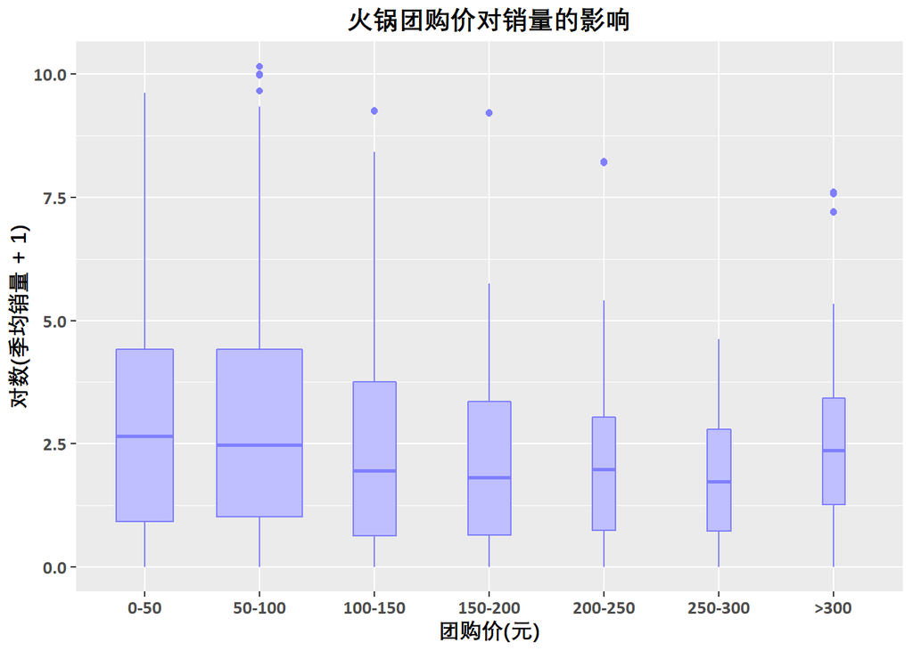

```r
## 离散化团购价为价格区间
hot.pot$price.interval[hot.pot$price < 50] <- '0-50'
hot.pot$price.interval[hot.pot$price >= 50 & hot.pot$price < 100] <- '50-100'
hot.pot$price.interval[hot.pot$price >= 100 & hot.pot$price < 150] <- '100-150'
hot.pot$price.interval[hot.pot$price >= 150 & hot.pot$price < 200] <- '150-200'
hot.pot$price.interval[hot.pot$price >= 200 & hot.pot$price < 250] <- '200-250'
hot.pot$price.interval[hot.pot$price >= 250 & hot.pot$price < 300] <- '250-300'
hot.pot$price.interval[hot.pot$price >= 300] <- '>300'

## 修改价格区间的顺序
hot.pot$price.interval <- factor(hot.pot$price.interval,
                                 c('0-50', '50-100', '100-150', '150-200', '200-250', '250-300', '>300'))

## 绘制团购价对销量的箱线图
ggplot(hot.pot, aes(price.interval, log.quarterly.sales.volume)) +
    geom_boxplot(outlier.colour = '#7F7FFF', fill = '#BFBFFF', color = '#7F7FFF', varwidth = T) +
    labs(x = '团购价(元)', y = '对数(季均销量 + 1)', title ='火锅团购价对销量的影响') +
    theme(title = element_text(family = 'chineseFont', face = 'bold', size = 12)) +
    theme(plot.title = element_text(hjust = 0.5)) +
    theme(axis.text.x = element_text(family = 'mathFont', face = 'bold', size = 10)) +
    theme(axis.text.y = element_text(family = 'mathFont', face = 'bold', size = 10))
```

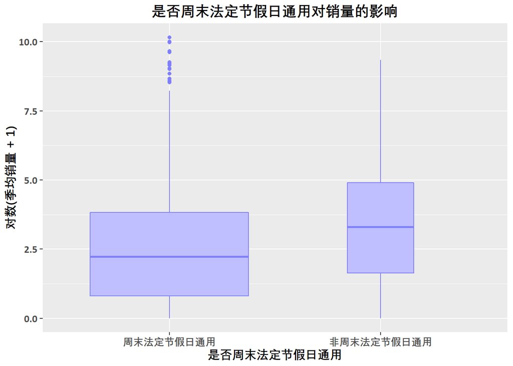

```r
## 修改节假日通用的顺序
hot.pot$if.nonworkdays.available <- factor(hot.pot$if.nonworkdays.available,
                                           c('周末法定节假日通用', '非周末法定节假日通用'))

## 绘制节假日通用对销量的箱线图
ggplot(hot.pot, aes(hot.pot$if.nonworkdays.available, log.quarterly.sales.volume)) +
    geom_boxplot(outlier.colour = '#7F7FFF', fill = '#BFBFFF', color = '#7F7FFF', varwidth = T) +
    labs(x = '是否周末法定节假日通用', y = '对数(季均销量 + 1)', title ='是否周末法定节假日通用对销量的影响') +
    theme(title = element_text(family = 'chineseFont', face = 'bold', size = 12)) +
    theme(plot.title = element_text(hjust = 0.5)) +
    theme(axis.text.x = element_text(family = 'chineseFont', face = 'bold', size = 10)) +
    theme(axis.text.y = element_text(family = 'mathFont', face = 'bold', size = 10))
```

## **TASK 6**

制作团购评分与销量的散点图，可以发现大部分数据聚集在右侧，即4-5分的范围内，另一方面评分为0的团购券也较多，总体上来看，评分越高，销量越高。但评分高不一定就包含智能销量高，这是因为某些小众火锅店质量很高但知名度不高。评分为0的团购券应该是客户买到团购券之后的对火锅店的反应，表明某些火锅团购的质量仍待提高。

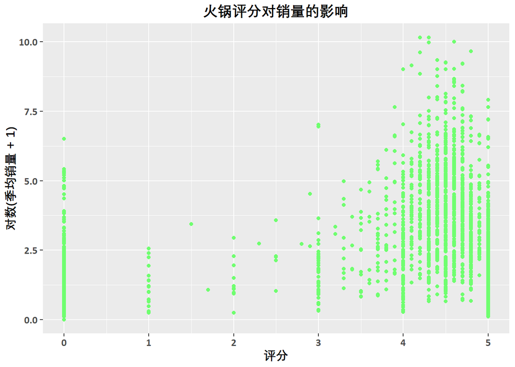

```r
## 绘制团购评分对销量的散点图
ggplot(hot.pot, aes(hot.pot$'评分', log.quarterly.sales.volume)) +
    geom_point(color = '#6FFF6F') +
    labs(x = '评分', y = '对数(季均销量 + 1)', title ='火锅评分对销量的影响') +
    theme(title = element_text(family = 'chineseFont', face = 'bold', size = 12)) +
    theme(plot.title = element_text(hjust = 0.5)) +
    theme(axis.text.x = element_text(family = 'mathFont', face = 'bold', size = 10)) +
    theme(axis.text.y = element_text(family = 'mathFont', face = 'bold', size = 10))
```

## **TASK 7**

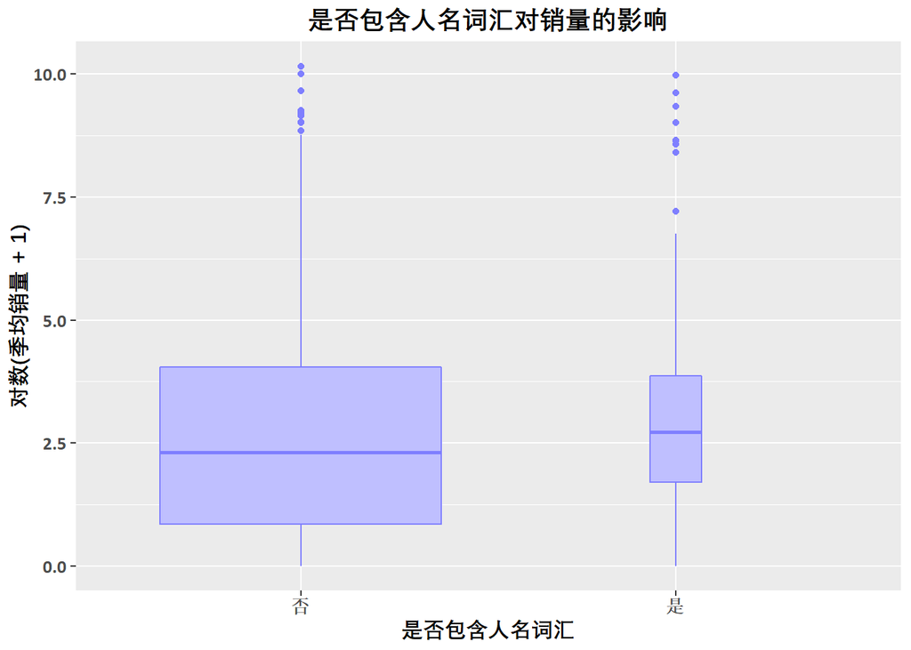

```r
## 设置人名识别分词
segment.options(isNameRecognition = T)

## 进行人名识别分词
words <- segmentCN(hot.pot$merchant.name, nature = T)

## 标记包含人名词汇的商家
flag = ''
for(i in 1:nrow(hot.pot))
{
    for(j in length(words[[i]]))
    {
        if(names(words[[i]][j]) == 'nr')
        {
            hot.pot$name[i] <- '是'
            flag = 'r'
        }
        if(flag != 'r')
        {
            hot.pot$name[i] <- '否'
        }
    }
}

## 修改人名分类变量的顺序
hot.pot$name <- factor(hot.pot$name, c('否', '是'))

## 绘制人名分类变量对销量的箱线图
ggplot(hot.pot, aes(name, log.quarterly.sales.volume)) +
    geom_boxplot(outlier.colour = '#7F7FFF', fill = '#BFBFFF', color = '#7F7FFF', varwidth = T) +
    labs(x = '是否包含人名词汇', y = '对数(季均销量 + 1)', title ='是否包含人名词汇对销量的影响') +
    theme(title = element_text(family = 'chineseFont', face = 'bold', size = 12)) +
    theme(plot.title = element_text(hjust = 0.5)) +
    theme(axis.text.x = element_text(family = 'mathFont', face = 'bold', size = 10)) +
    theme(axis.text.y = element_text(family = 'mathFont', face = 'bold', size = 10))
```

## **TASK 8**

采用团购销售的中位数9作为分类标准，将季均销量大于9的数据标记为高销量，用于下面的逻辑回归分析。

```r
## 转换团购销量为分类因变量
hot.pot$high.volume.interval[hot.pot$quarterly.sales.volume > 9] <- 1    ## 高销量水平
hot.pot$high.volume.interval[hot.pot$quarterly.sales.volume <= 9] <- 0    ## 低销量水平

## 提取逻辑回归所需的子数据集
hot.pot.glm <- hot.pot[, c('high.volume.interval', 'discount', 'price', 'privilege.for.new',
                           'privilege.on.sale', 'district', 'if.nonworkdays.available',
                           'time.duration', 'if.appointment.needed', 'WiFi.available',
                           'parking', 'rooms.available', '评分', 'online.intervel',
                           'level.of.participants.limited', 'level.of.tickets.limited',
                           'place', 'food', 'taste', 'cook', 'people', 'style', 'HighFreq')]
```

## **TASK 9**

使用glm()函数进行逻辑回归建模，查看回归结果得到结论，新客优惠、节假日通用、上线天数、人数限制等变量影响程度较大。

```r
## 逻辑回归建模
hot.pot.model <- glm(high.volume.interval ~ log(price) + . - price,
                     family = binomial(), data = hot.pot.glm)

## 输出回归结果
summary(hot.pot.model)
```

```
##
## Call:
## glm(formula = high.volume.interval ~ log(price) + . - price,
##     family = binomial(), data = hot.pot.glm)
##
## Deviance Residuals:
##     Min       1Q   Median       3Q      Max
## -2.7266  -0.6208   0.1949   0.7879   3.0796
##
## Coefficients:
##                                                Estimate Std. Error z value
## (Intercept)                                  -2.3062007  0.6292149  -3.665
## log(price)                                   -0.2334015  0.0883635  -2.641
## discount                                      0.0740691  0.3634418   0.204
## privilege.for.new无钱包新客优惠               1.3475994  0.4081740   3.302
## privilege.on.sale有立减优惠                   0.8607474  0.2415962   3.563
## district碑林区                                1.1971371  0.2513703   4.762
## district高新区                                0.1697929  0.3028517   0.561
## district莲湖区                                0.7387774  0.2463166   2.999
## district临潼区                                0.0466579  0.2967912   0.157
## district未央区                                0.2481680  0.2351193   1.055
## district新城区                                0.4123163  0.2798015   1.474
## district阎良区                                1.5992887  0.3301921   4.844
## district雁塔区                                0.7843021  0.2433712   3.223
## district长安区                                0.5722580  0.2658310   2.153
## if.nonworkdays.available非周末法定节假日通用  0.8167245  0.1491835   5.475
## time.duration                                 0.0117998  0.0154449   0.764
## if.appointment.needed需预约                  -0.7170453  0.2003865  -3.578
## WiFi.available未提及                         -0.9131233  0.1361793  -6.705
## parking收费停车位                            -0.2553209  0.2199241  -1.161
## parking未提及                                 0.0473069  0.1459466   0.324
## parking无停车位                              -0.0955000  0.1628492  -0.586
## rooms.available均可使用                      -0.0773700  0.1328309  -0.582
## rooms.available未提及                         0.4773188  0.2547231   1.874
## 评分                                          0.6951270  0.0317666  21.882
## online.intervel                              -0.0017706  0.0002776  -6.377
## level.of.participants.limited限1人            0.8800539  0.2863825   3.073
## level.of.participants.limited限2-4人         -0.2268988  0.1314673  -1.726
## level.of.participants.limited限5-12人        -0.7350912  0.1877230  -3.916
## level.of.tickets.limited限制张数              0.2109818  0.1385245   1.523
```

[output cut: 43 more lines]

```
## people是                                     0.002657 **
## style川系                                    0.046312 *
## style其他                                    0.004948 **
## style粤系                                    0.876120
## HighFreq                                     0.768826
## ---
## Signif. codes:  0 '***' 0.001 '**' 0.01 '*' 0.05 '.' 0.1 ' ' 1
##
## (Dispersion parameter for binomial family taken to be 1)
##
##     Null deviance: 3726.2  on 2687  degrees of freedom
## Residual deviance: 2531.0  on 2650  degrees of freedom
## AIC: 2607
##
## Number of Fisher Scoring iterations: 5
```

## **TASK 10**

由以上得到的数据绘制ROC曲线，得到AUC值为0.84，这个值表明逻辑回归的效果较好，一般来说AUC值越大，回归效果越好。正例率在低负例率时较高表明模型比较准确。

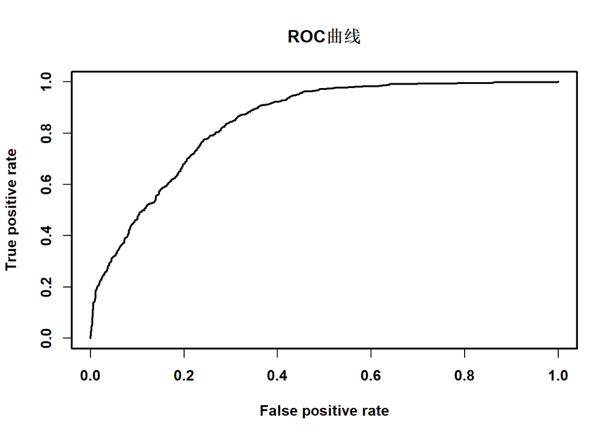

```r
## 生成预测结果数据集hot.pot.pred
hot.pot.pred <- predict(hot.pot.model, data = hot.pot)

## 计算预测概率prob
hot.pot.glm$prob <- exp(hot.pot.pred) / (1 + exp(hot.pot.pred))

## 生成prediction对象predObj
predObj <- prediction(hot.pot.glm$prob, hot.pot.glm$high.volume.interval)

## 计算ROC值hot.pot.roc
hot.pot.roc <- performance(predObj, 'tpr', 'fpr')

## 设置绘图格式
par(font.main = 2, font.axis = 2, font.lab = 2, lwd = 2, pch = 1)

## 绘制ROC曲线
plot(hot.pot.roc, main = 'ROC曲线')
```

```r
## 计算AUC值
performance(predObj, 'auc') @ y.values
```

```
## [[1]]
## [1] 0.8455522
```